# RR - Week 2 Peer Assignment

Aravindan Krishnan

January 9, 2018

## Loading packages dplyr and lubridate

```r
library(dplyr)
library(lubridate)
```

## Reading and Processing the Data (Remove NA values)

```r
### 1.Load the data (i.e. read.csv())
activitymondata <- read.csv("C:/Users/aravindan.krishnan/Documents/clean data/activity.csv")
### Process the Data (Remove NA values)
validactivitymondata <- activitymondata[complete.cases(activitymondata),]
```

## What is mean total number of steps taken per day?

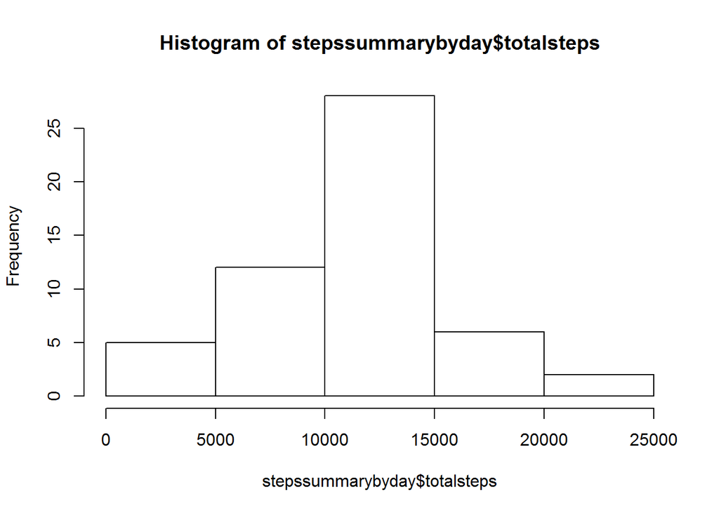

```r
### 1.Calculate the total number of steps taken per day
stepsbyday <- group_by(validactivitymondata,date)
stepssummarybyday <- summarize(stepsbyday,totalsteps=sum(steps))
### Make a histogram of the total number of steps taken each day
hist(stepssummarybyday$totalsteps)
```

```r
### Calculate and report the mean of the total number of steps taken per day
mean(stepssummarybyday$totalsteps)
```

```
## [1] 10766.19
```

```r
### Calculate and report the median of the total number of steps taken per day
median(stepssummarybyday$totalsteps)
```

```
## [1] 10765
```

## What is the average daily activity pattern?

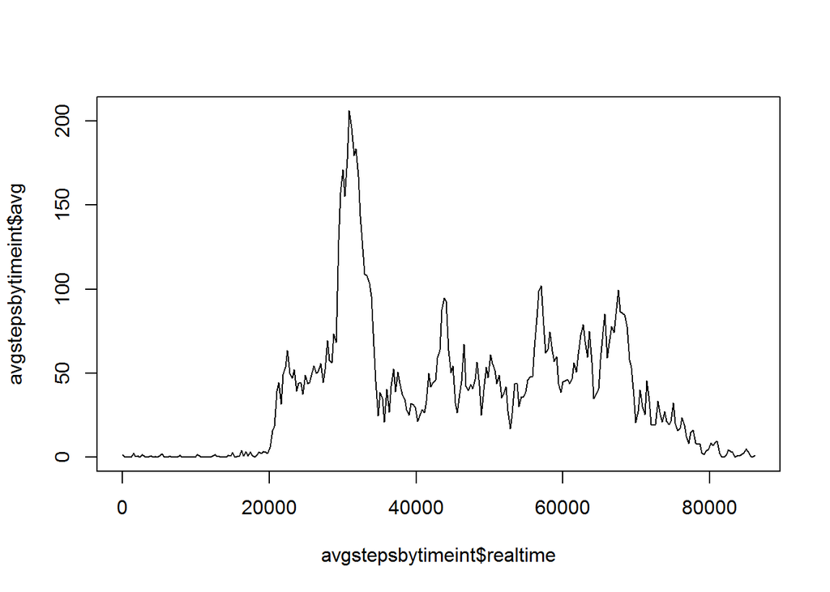

```r
# Add leading zeros to minutes - eg: convert 5 minutes to 0005
int <- sprintf("%04d",validactivitymondata$interval)
# convert to HH:MM:SS still in char format only
validactivitymondata$time <- format(strptime(int, format="%H%M"), format = "%H:%M:%S")
 # Group by time intervals
grpbytimeint <- group_by(validactivitymondata,time)
# calculate avg steps by grouped time interval
avgstepsbytimeint <- summarize(grpbytimeint, avg=mean(steps))
# convert to real time format so that the time variable can be used in time series plotting
avgstepsbytimeint$realtime <- hms(avgstepsbytimeint$time)
# create empty plot
plot(avgstepsbytimeint$realtime,avgstepsbytimeint$avg, type = "n")
# Add lines to plot
lines(avgstepsbytimeint$realtime,avgstepsbytimeint$avg)
```

```r
# 2.Which 5-minute interval, on average across all the days in the dataset, contains the maximum number of steps?
filter(avgstepsbytimeint, avg == max(avgstepsbytimeint$avg))
```

```
## # A tibble: 1 x 3
##       time      avg     realtime
##      <chr>    <dbl> <S4: Period>
## 1 08:35:00 206.1698           0S
```

## Imputing missing values

### 1.Calculate and report the total number of missing values in the dataset (i.e. the total number of rows with NAs)

```r
table(is.na(activitymondata))# How many NAs - check for count under TRUE
```

```
##
## FALSE  TRUE
## 50400  2304
```

### 2.Devise a strategy for filling in all of the missing values in the dataset. The strategy does not need to be sophisticated. For example, you could use the mean/median for that day, or the mean for that 5-minute interval, etc. 3.Create a new dataset that is equal to the original dataset but with the missing data filled in.

```r
totalint <- sprintf("%04d",activitymondata$interval)
activitymondata$time <- format(strptime(totalint, format="%H%M"), format = "%H:%M:%S")
grpbytotaltimeint <- group_by(activitymondata,time)
avgstepsbytotaltimeint <- summarize(grpbytotaltimeint, avg=mean(steps, na.rm = TRUE))
joinactivitymondata <- inner_join(activitymondata, avgstepsbytotaltimeint, by = c("time" = "time"))
joinactivitymondata[is.na(joinactivitymondata),]$steps <- joinactivitymondata[is.na(joinactivitymondata),]$avg
head(select(joinactivitymondata, -avg))
```

```
##       steps       date interval     time
## 1 1.7169811 2012-10-01        0 00:00:00
## 2 0.3396226 2012-10-01        5 00:05:00
## 3 0.1320755 2012-10-01       10 00:10:00
## 4 0.1509434 2012-10-01       15 00:15:00
## 5 0.0754717 2012-10-01       20 00:20:00
## 6 2.0943396 2012-10-01       25 00:25:00
```

### 4.Make a histogram of the total number of steps taken each day and Calculate and report the mean and median total number of steps taken per day. Do these values differ from the estimates from the first part of the assignment? What is the impact of imputing missing data on the estimates of the total daily number of steps?

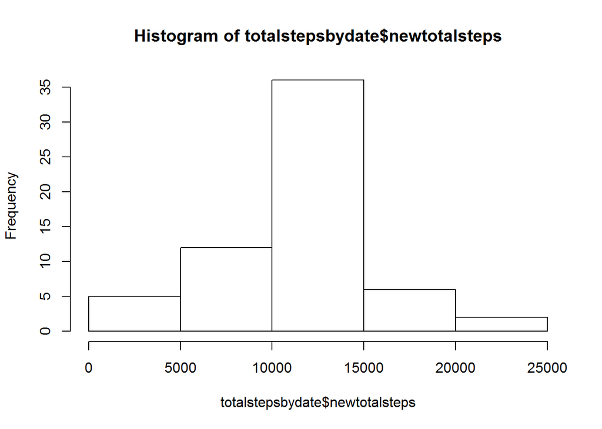

```r
grpbydate <- group_by(joinactivitymondata, by=date)
totalstepsbydate <- summarize(grpbydate, newtotalsteps=sum(steps))
hist(totalstepsbydate$newtotalsteps)
```

```r
mean(totalstepsbydate$newtotalsteps)
```

```
## [1] 10766.19
```

```r
median(totalstepsbydate$newtotalsteps)
```

```
## [1] 10766.19
```

## Are there differences in activity patterns between weekdays and weekends?

### 1.Create a new factor variable in the dataset with two levels - “weekday” and “weekend” indicating whether a given date is a weekday or weekend day.

```r
joinactivitymondata$date <- as.Date(joinactivitymondata$date)
for(i in 1:length(joinactivitymondata$date)){
if(weekdays(joinactivitymondata$date[i]) %in% c("Monday", "Tuesday","Wednesday","Thursday","Friday")){
  joinactivitymondata$daytype[i] <- "weekday"
} else {
    joinactivitymondata$daytype[i] <- "weekend"
}
}
head(joinactivitymondata)
```

```
##       steps       date interval     time       avg daytype
## 1 1.7169811 2012-10-01        0 00:00:00 1.7169811 weekday
## 2 0.3396226 2012-10-01        5 00:05:00 0.3396226 weekday
## 3 0.1320755 2012-10-01       10 00:10:00 0.1320755 weekday
## 4 0.1509434 2012-10-01       15 00:15:00 0.1509434 weekday
## 5 0.0754717 2012-10-01       20 00:20:00 0.0754717 weekday
## 6 2.0943396 2012-10-01       25 00:25:00 2.0943396 weekday
```

### 2.Make a panel plot containing a time series plot (i.e. type = “l”) of the 5-minute interval (x-axis) and the average number of steps taken, averaged across all weekday days or weekend days (y-axis). See the README file in the GitHub repository to see an example of what this plot should look like using simulated data.

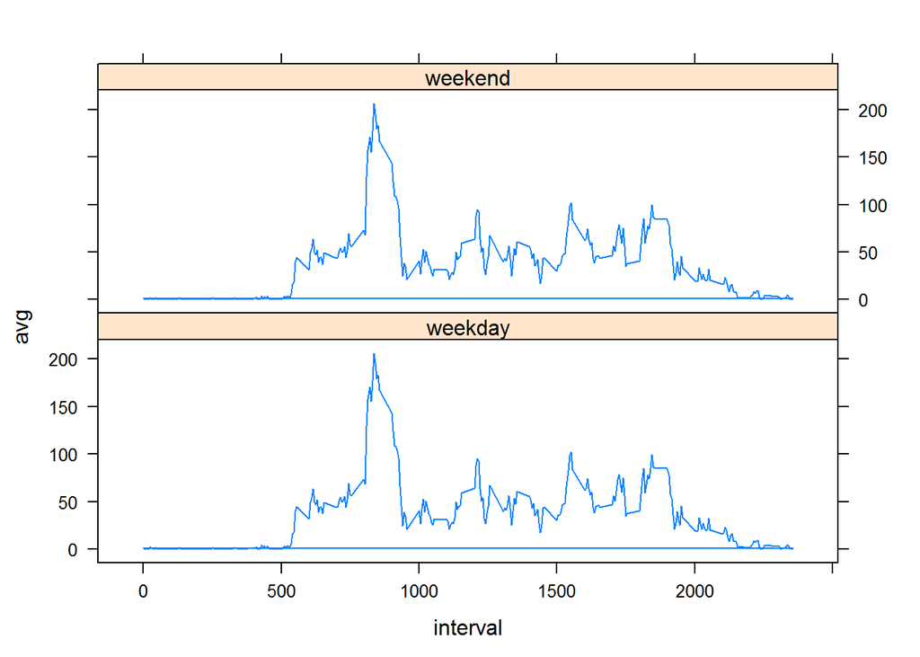

```r
library(lattice)
joinactivitymondata$daytype <- as.factor(joinactivitymondata$daytype)
xyplot(avg~interval | daytype, data=joinactivitymondata, type="l", layout=c(1,2))
```